# Recreating plots using ggplot2

Anders Jensen

2024-11-06

## Data Visualisation in Rstudio using GGPlot2

This file will provide you with three worked examples of how to implement the ggplot2 package to recreate plots you see online.

### How to use this document

Firstly visit the links for each example to find the plot we are trying to recreate. This idea was inspired by the Riffomonas youtube channel and I would highly recommend subscribing to the Riffomonas newsletter as well as youtube channel for more worked examples (see below).

[Riffomonas Newsletter](https://shop.riffomonas.org/posts)

[Riffomonas Youtube](https://www.youtube.com/@Riffomonas)

Firstly you will need to install and load required packages and then create an example dataset to build your plot.

Then you can run the code to make the plot. To understand what each line does you can remove it from the original code to see the difference.

### Required packages

The following packages will be needed to recreate these plots, make sure you install and load them correctly.

```r
library(dplyr)
library(ggplot2)
library(ggrepel)
library(scales)
library(tibble)
library(viridis)
library(grid)
library(png)
```

## Plot 1

### Link to example plot

[Plot 1 Webpage](https://shop.riffomonas.org/posts/developing-intuition-about-how-to-build-analyses)

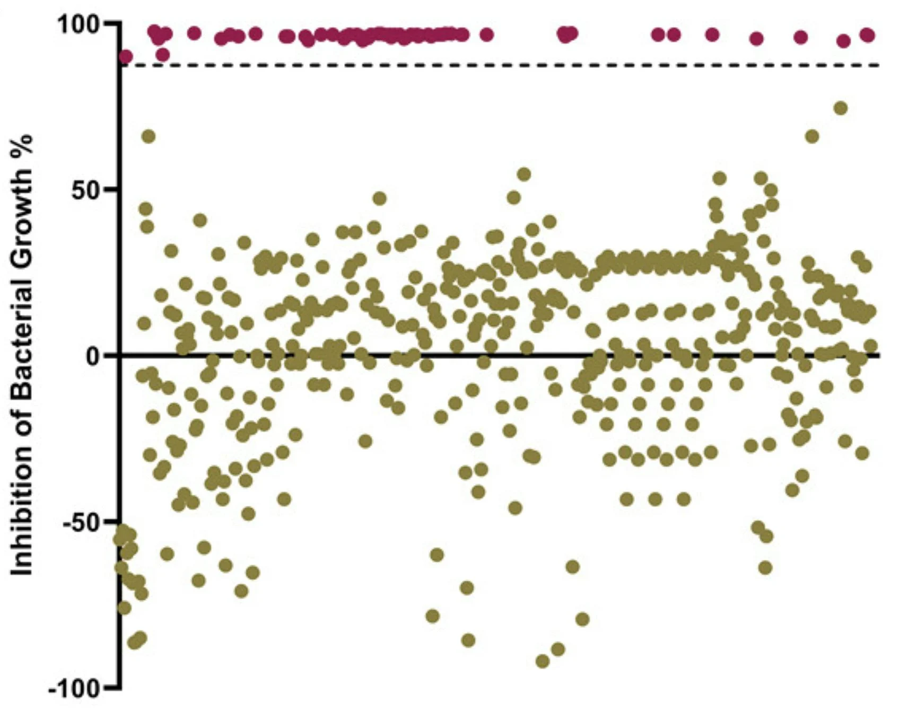

As you can see we have a plot showing the effect of different compounds on bacterial growth. It can also be seen that any compounds with a minimum of 90% efficacy are highlighted in red.

### Generate example data

```r
scores <- c(runif(n = 527-63, min = -90, max = 90),
            runif(n = 63, min = 90, max = 100))

df <- data.frame(scores = scores) %>%
  mutate(group = case_when(scores >= 90~"strong hit",
                           scores < 90~"weak hit"))
```

### Remake the plot

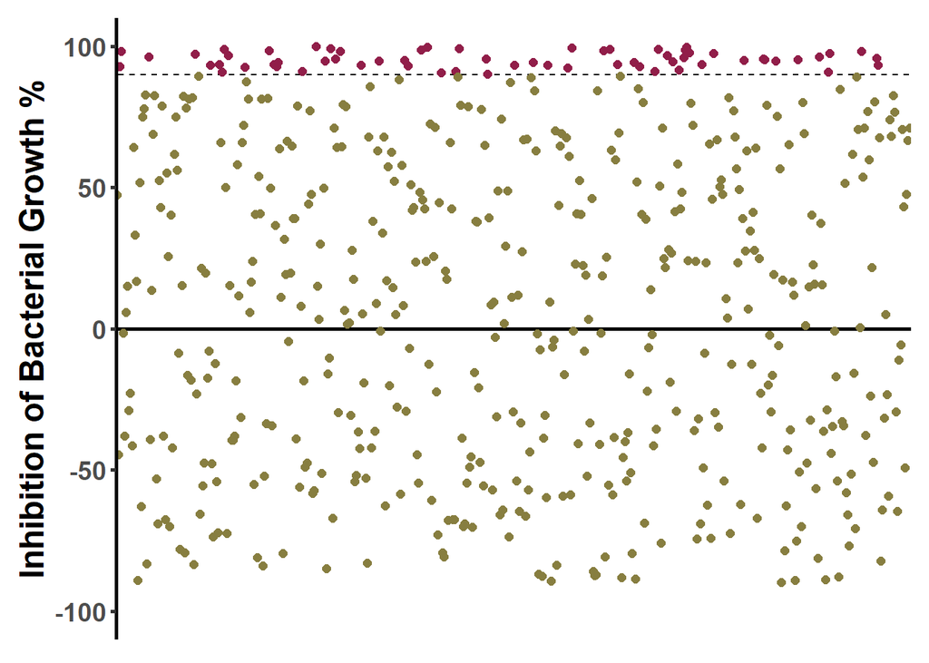

```r
df %>%
  sample_frac(n = n()) %>% # randomise order
  ggplot(aes(y = scores, x = rownames(df)))+ # build base ggplot
  geom_abline(intercept = 0, slope = 0, linewidth = 1)+ # add line at y = 0
  geom_abline(intercept = 90, slope = 0, linetype = 2)+ # add line at y = 90
  geom_point(aes(col = group), show.legend = F, size = 2)+ # add the points
  theme(axis.title.x = element_blank(), # remove x axis title
        axis.text.x = element_blank(), # remove x axis text
        axis.text.y = element_text(size = 14, face = "bold"),# axis text y
        axis.title.y = element_text(face = "bold", size = 18), # axis title y
        axis.ticks.y = element_line(linewidth = 1),# change axis ticks
        axis.line.y = element_line(linewidth = 1),# changes axis line
        axis.ticks.x = element_blank(),# remove x ticks
        panel.background = element_rect(fill = "white"),# make background white
        plot.margin = margin(t = 10, r = 10, b = 10, l = 10))+# increase margin around plot
  labs(y = "Inhibition of Bacterial Growth %")+# Sort out y axis name
  coord_cartesian(xlim = NULL, ylim = c(-100, 100),expand = T)+# set the axis limits
  scale_color_manual(values = c("#911e49" ,"#877e40"))# change colours
```

As you can see although the data may be slightly different, the overall design of the plot is very similar.

To pick the correct colours for the plot, I used an online tool (See below).

[Colour Picker](https://imagecolorpicker.com/)

## Plot 2

### Link to example plot

[Plot 2 Webpage](https://shop.riffomonas.org/posts/check-out-this-scatter-plot-with-annotation-in-swedish)

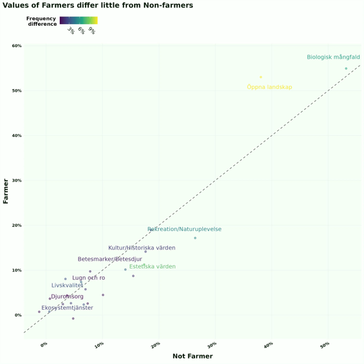

For more information on the data plotted here, visit the link above.

### Generate example data

```r
sports <- c("Football", "Basketball", "Baseball", "Tennis", "Golf", "Swimming", "Cycling", "Boxing",
            "Wrestling", "Running", "Cricket", "Rugby", "Hockey", "Table Tennis", "Volleyball",
            "Badminton", "Skating", "Skiing", "Surfing", "Archery")
survey <- tibble(value = sports,
                 no_noise = c(seq(1, 30, length = 18), 40, 50),
                 athlete = abs(no_noise + runif(20, min = -10, max = 10)),
                 non_athlete = abs(no_noise + runif(20, min = -10, max = 10))) %>%
  select(-no_noise) %>%
  mutate(diff = abs(non_athlete-athlete))
```

### Remake the plot

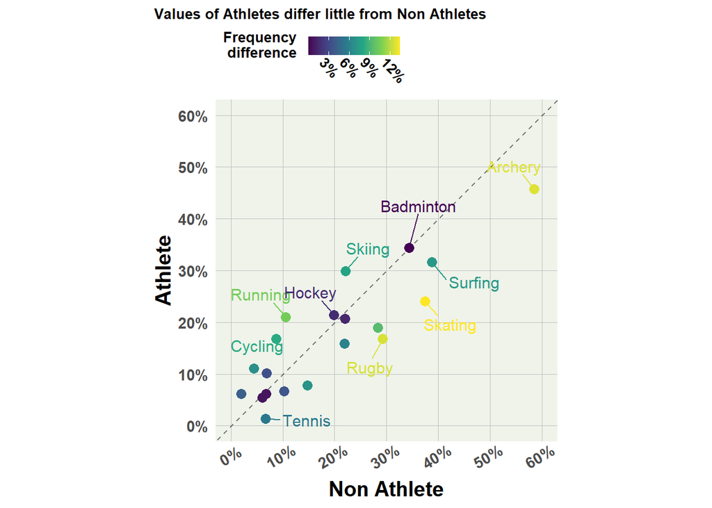

```r
survey %>%
  ggplot(aes(x = non_athlete, y = athlete))+ # base ggplot
  geom_abline(intercept = 0,slope = 1,linetype = 2,alpha = 0.5)+ # add line with equation y = x
  geom_point(aes(col = diff),size = 3)+ # add points
  labs(x = "Non Athlete",y = "Athlete",title = "Values of Athletes differ little from Non Athletes",# edit labels
       col = "Frequency \n difference")+# edit labels
  scale_color_viridis_c(labels = scales::percent_format(scale = 1), breaks = seq(0, 15, 3))+# change colours based on diff
  coord_equal(xlim = c(0,60),# set axis limits
              ylim = c(0,60))+
  theme(axis.title = element_text(size = 15,
                                  face = "bold"),# axis title
        axis.text.x = element_text(size = 11,
                                   face = "bold",
                                   angle = 30,
                                   hjust = 0.7),# axis text x
        axis.text.y = element_text(size = 11,
                                   face = "bold"),# axis text y
        legend.title = element_text(face = "bold",
                                    size = 10,
                                    vjust = 1.2),# legend title
        legend.text = element_text(size = 10,
                                   face = "bold",
                                   angle = 315, hjust = -0, vjust = 1.3,
                                   margin = margin(t = 0)),# legend text
        legend.box.spacing = unit(0, "pt"),# moves legend closer to plot
        legend.key.size = unit(13, "pt"),# makes legend bigger
        plot.title = element_text(face = "bold", size = 10),# edit title
        plot.title.position = "plot",# moves title position
        legend.position = 'top',# moves legend
        legend.justification = "left",# moves legend
        panel.grid.minor = element_blank(),# removed grid lines
        panel.grid.major = element_line(colour = "grey", linewidth = 0.25),# change colour of background lines
        panel.background = element_rect(fill = "#EFF3EA"),# make background a different colour
        axis.ticks = element_blank())+# remove ticks
  scale_x_continuous(labels = scales::percent_format(scale = 1), breaks = seq(0, 60, 10))+# makes scale a percentage
  scale_y_continuous(labels = scales::percent_format(scale = 1), breaks = seq(0, 60, 10))+# makes scale a percentage
  geom_text_repel(aes(label = value, # adds labels
                      col = diff),# sets colour of labels
                  min.segment.length = 0, # forces line
                  size = 4, # size of text
                  box.padding = 0.75, # length of line
                  point.padding = 0.1)# moves the line slightly away from the point
```

Again a lot of code to make this plot but you can see the final outcome is very similar to the example.

## Plot 3

### Link to example plot

[Plot 3 Webpage](https://mathmonks.com/bar-graphs/horizontal-bar-graph)

[figure not shown]

Plot 3 Inspiration

### Generate example data

```r
df <- data.frame(vehicle = c("Bus", "Car", "Train", "Bike", "Walking"),
                 number = c(26, 41, 13, 8, 12))
```

### Remake the plot

Before making the plot we can see that there is an image on the plot so we must first save that logo as a png file.

You can use any image you want for this but just make sure you save it as a png file.

From the following code you will need to change the path to the image you use.

[figure not shown]

```r
path_to_image <- "../Plot 3/logo.png"# specify image path

df %>%
  mutate(vehicle = factor(vehicle,levels = rev(c("Bus", "Car", "Train", "Bike", "Walking")))) %>%# ensure correct order
  ggplot(aes(x = number, y = vehicle))+# base ggplot
  geom_bar(aes(col = vehicle, fill = vehicle),# add the bars
           stat = "identity", width = 0.7, show.legend = F)+
  labs(x = "Number of Students",
       y = "Transport",
       title = "Modes of Transport",
       subtitle = "Scale: 1 unit = 10 students")+# change labels
  theme(axis.title.x = element_text(colour = "#70b443", size = 15),
        axis.text.x = element_text(colour = "#70b443", size = 12),
        axis.title.y = element_text(colour = "#e77048", size = 15),
        axis.text.y = element_text(colour = "#e77048", size = 12, margin = margin(r = 2)),# edit axis text and titles
        plot.title.position = "plot",# change title position
        plot.title = element_text(size = 20, hjust = 0.5, colour = "#1e4b62", face = "bold"),# move title to middle
        plot.subtitle = element_text(size = 14, colour = "#590067",hjust = 1),# move subtitle
        panel.grid.minor.y = element_blank(),
        panel.grid.major.y = element_blank(),
        panel.grid.minor.x = element_line(colour = "#94b0bc"),
        panel.grid.major.x = element_line(colour = "#94b0bc"),# edit panel grids
        panel.background = element_blank(),# remove panel background
        axis.ticks = element_blank(),# remove ticks
        axis.line = element_line(linewidth = 1, colour = "#2d607b"),# add axis lines
        plot.margin = margin(t = 20, r = 20, b = 20, l = 20))+# increase white space
  scale_x_continuous(breaks = seq(0, 55, 10),# change the breaks
                     minor_breaks = seq(0, 55, 10),
                     expand = c(0,0))+# move y axis closer to bars
  coord_cartesian(xlim = c(0, 52))+# add limits
  scale_fill_manual(values = rev(c("#7da7d9", "#ed8586", "#8d1d1c", "#70b443", "#e56542")))+# change colours
  scale_color_manual(values = rev(c("#7da7d9", "#ed8586", "#8d1d1c", "#70b443", "#e56542")))+
  annotation_custom(rasterGrob(readPNG(path_to_image),
                               width = unit(0.1, "npc"),
                               height = unit(0.2, "npc")),
                    xmin = 30,
                    xmax = 70,
                    ymin = 3,
                    ymax = 7)# add on the image
```

## Conclusion

Have a go at recreating these plots and if you are feeling confident, try to recreate more plots that you are able to find online.